# STAT 340 Final Report

12/18/2021

Names/NetID:

- Justin Chan: jachan
- Tambre Hu: thu53
- Oat Sukcharoenyingyong: sukcharoenyi
- James Ma: yma255
- Shawn Riemer: seriemer

# 1 Abstract

> An abstract of at most 300 words giving an overview of your data, the question(s) you tried to answer, and a brief summary of your findings.

# 2 Dataset

> A brief introduction describing your data set: where it came from, who gathered it and a brief description of why your group found this data interesting and why your reader should care. If you obtained your data set from Kaggle or a similar repository, it is not enough to simply say “This was collected by user xyz and posted to Kaggle”. You should be able to explain the specific source of your data.

The data was compiled by the World Bank, an international financial organization that provides support for lower-income countries. They track the indicators found in this dataset and compile them for anayone to use. Our group was drawn to this dataset because of its importance and relevance. The indicators included comprise some of the most discussed and debated inequalities between countries. While we cannot solve these inequalities just by looking at data, we are excited to investigate and identify prominent relationships between features.

# 3 Variables

> A description of the variables available in your data set, with more details for the variables that are likely to be relevant to your question (you may copy-paste this from your previous drafts, if you wish).

With 1,344 total unique indicators there are too many to name them all, but we will focus on a handful of them. For our economic analysis, we will use `GDP_per_capita_(current_US$)`, which is a country’s economic output per citizen adjusted to the United States Dollar currency. There are many variations of GDP in the dataset, but GDP per capita is commonly used to compare the economic states of different countries, so we will use that one. A couple of variables that we expect impact a country’s economic strenght are unemployment rate, `Unemployment,_total_(%_of_total_labor_force)`, and relative military expenditure, `Military_expenditure_(%_of_GDP)`.

Of the health indicators, one variable we will look at is `Adolescent_fertility_rate_(births_per_1,000_women_ages_15-19)`. Adolescent fertility rate is the rate of births per 1,000 women aged 15-19 years old, and is often used as a healthcare metric, so we expect it to be related to GDP per capita. Another indicator that we expect to impact GDP per capita is `Population_ages_65_and_above_(%_of_total)`, the percent percent of citizens 65 years or older. Other metrics related to health that we expect to find important include those related to health expenditure, `Health_expenditure,_total_(%_of_GDP)`, and life expectancy, `Life_expectancy_at_birth,_total_(years)`.

Many other assorted metrics are included in the dataset. Environmental metrics such as CO2 emmisions, `CO2_emissions_(metric_tons_per_capita)`, will be interesting to investigate against economic metrics. Other indicators we expect to correlate with economic strength are internet users, `Internet_users_(per_100_people)`, and urban population, `Urban_population_(%_of_total)`, although plenty of indicators not mentioned here will also be analyzed.

# 4 Statistical Question

> A discussion of your statistical question of interest.

The vast amount of data meant that there was a lot to explore, but we decided to focus on answering the following question:

1. What indicators have the greatest impact on a country’s GDP per capita?
1. Are there relationships between those indicators?
2. Can we use these indicators to predict a country’s GDP per capita?
1. How does that compare with other prediction methods?

For our first statistical question, given the various metrics we have in our data, we thought it would be interesting to see how different factors impact a country’s GDP per capita since that is a relatively prominent indicator of a country’s economic health. We chose to use GDP as the deciding metric for comparison since it gives information about the size of the economy and how an economy is performing. The growth rate of GDP is often used as an indicator of the general health of the economy, so in a broader sense, an increase in real GDP is interpreted as a sign that the economy is doing well. We also thought figuring out if there are any relationships between said metrics would be interesting because along with knowing what indicators have the greatest impact on a country’s GDP, being able to pinpoint how those indicators are related and if they’re all part of a certain category, for instance, if the most impactful metrics were all related to healthcare, we would be able to gain a more general insight on what general system of a country impacts it’s GDP and economy.

Our second statistical question delves into the relationship between the indicators we are looking for and GDP. We wanted to find out if we could use the indicators we found to predict a country’s GDP because, hypothetically, we could be able to use the most impactful metrics that impact a country’s economy to predict how much, and to what extent that impact would be. Along with this, since the end goal of us asking this question is to derive a successful GDP model predictor, we also wanted to look into if using the most impactful indicators is the best metric for prediction by comparing the results of that model with other prediction methods.

# 5 Analysis

> A summary, including as many plots, tables, R model outputs, etc as necessary to show how you tried to answer your statistical question. You should explain the reasoning behind your decisions to use particular methods, models or tests. This summary need not include only successes– if you tried something that turned out not to work, take some time to discuss it, why it might not have worked, and how your might fix the problem given more time.

## 5.1 PCA, kmeans, clustering

### 5.1.1 Doing PCA and kmeans

```r
# At this point the data frame we want to use is called `ind5`. Doing PCA and kmeans clustering.
gdp_per_capita_current_US <- ind5 %>%
  select("GDP_per_capita_(current_US$)")
predictors <- ind5 %>%
  select(-"GDP_per_capita_(current_US$)", -"CountryName")

pc3 <- prcomp(predictors, scale = TRUE, rank. = 2)
km3 <- kmeans(pc3$x, centers = 5, nstart = 10)

pcs <- pc3$x %>% data.frame()

foo <-
  cbind(ind5, pcs) %>% select(CountryName, PC1, PC2, everything())

foo$Cluster = km3$cluster

# foo %>%
#   select(contains("GDP"),
#          contains("GNI"))

foo <- foo %>% select(CountryName, Cluster, PC1, PC2, everything())
```

### 5.1.2 Pairs plot

Pairs plot with arbitrarily chosen indicators to show clustering:

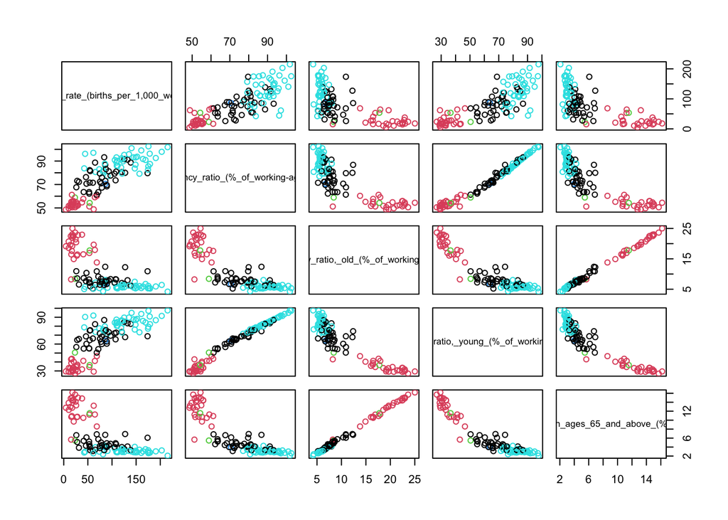

```r
# Pairs plot
pairs(foo[, 5:9], col = foo$Cluster)
```

### 5.1.3 Hierarchical clustering

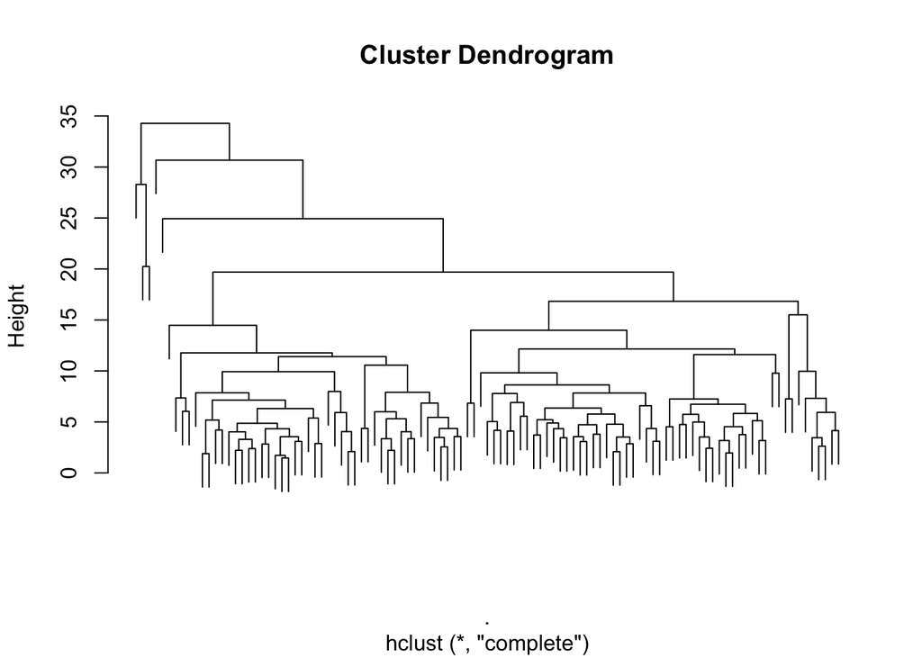

```r
# heir clustering
foo[, 5:75] %>% scale() %>% data.frame() %>% dist() %>% hclust() %>% plot(labels = FALSE)
```

### 5.1.4 Linear model on PCA

```r
# Linear model using PCA
y <- gdp_per_capita_current_US
x <- prcomp(predictors, scale = TRUE, rank. = 5)$x %>% data.frame()
goo <- cbind(y, x) %>% rename(gdp_usd = `GDP_per_capita_(current_US$)`)
model <- lm(gdp_usd ~ PC1 + PC2 + PC3 + PC4 + PC5, goo)
# model %>% summary()
```

```r
n = 107
k = 5
grp_sz <- floor(n / k)

# want to split x and y into grp_sz
x <- prcomp(predictors, scale = TRUE, rank. = 5)$x %>% data.frame()
y <- gdp_per_capita_current_US

## FUNCTION (x, y)
k_ = 1
xs <- list()
ys <- list()
for (i in 1:n) {
  if ((i-1) %% grp_sz == 0) {
    if ((i + (grp_sz*2)) >= n) {
      gr_x <- x[i:(n),]
      gr_y <- y[i:(n),]
    } else {
      gr_x <- x[i:(i+grp_sz),]
      gr_y <- y[i:(i+grp_sz),]
    }
    xs[[k_]] <- gr_x
    ys[[k_]] <- gr_y
    k_ <- k_ + 1
  }
}

xs <- xs[1:length(xs)-1]
ys <- ys[1:length(ys)-1]

# for (gr in xs[2:length(xs)]) {
models <- list()
for (i in 1:length(xs)) {
  xs_ <- data.frame()
  ys_ <- data.frame()
  for (j in 1:length(xs)) {
    if (i != j) {
      xs_ <- bind_rows(xs_, xs[[j]])
      ys_ <- bind_rows(ys_, ys[[j]])
    }
  }
  x_ <- xs_
  y_ <- ys_
  goo <- cbind(y_, x_) %>% rename(gdp_usd = `GDP_per_capita_(current_US$)`)
  model <- lm(gdp_usd ~ PC1 + PC2 + PC3 + PC4 + PC5, goo)
  models[[i]] <- model
}
sqr <- function (x) {
  x * x
}

accr2 <- 0
acc <- 0
for (i in 1:length(xs)) {
  m <- models[[i]]
  foo <- cbind(predict(m, xs[[i]]) %>% data.frame(), ys[[i]]) %>%
  mutate(
    res = . - `GDP_per_capita_(current_US$)`,
    rse = res^2,
    rss = res ^ 2,
    tss = (. - mean(`GDP_per_capita_(current_US$)`))^2
  )
  r2 <- sum(foo$rss) / sum(foo$tss)
  acc <- acc + (foo$rse %>% mean())
  accr2 <- accr2 + r2

}

tibble(
  r2 = (r2 <- (accr2 / (models %>% length()))),
  mse = (acc / (models %>% length())),
  rmse = (acc / (models %>% length())) %>% sqrt()
)
```

| r2 | mse | rmse |
| --- | --- | --- |
| 0.5013026 | 22776755 | 4772.5 |

## 5.2 Model/test 2

```r
# grid <- 10 ^ seq(10,-2, length = 100)
grid <- c(0, 1, 2, 5, 10, 100, 500, 1000)

results <- tibble(
  lambda=-1, mse=-1, rmse=-1, r2=-1
)

for (lambda in grid) {
  # lambda = 5
  n = 107
  k = 5
  grp_sz <- floor(n / k)

  # want to split x and y into grp_sz
  x <- prcomp(predictors, scale = TRUE, rank. = 5)$x %>% data.frame()
  y <- gdp_per_capita_current_US

  ## FUNCTION (x, y)
  k_ = 1
  xs <- list()
  ys <- list()
  for (i in 1:n) {
    if ((i - 1) %% grp_sz == 0) {
      if ((i + (grp_sz * 2)) >= n) {
        gr_x <- x[i:(n), ]
        gr_y <- y[i:(n), ]
      } else {
        gr_x <- x[i:(i + grp_sz), ]
        gr_y <- y[i:(i + grp_sz), ]
      }
      xs[[k_]] <- gr_x
      ys[[k_]] <- gr_y
      k_ <- k_ + 1
    }
  }

  xs <- xs[1:length(xs) - 1]
  ys <- ys[1:length(ys) - 1]

  # for (gr in xs[2:length(xs)]) {
  models <- list()
  for (i in 1:length(xs)) {
    xs_ <- data.frame()
    ys_ <- data.frame()
    for (j in 1:length(xs)) {
      if (i != j) {
        xs_ <- bind_rows(xs_, xs[[j]])
        ys_ <- bind_rows(ys_, ys[[j]])
      }
    }
    x_ <- xs_
    y_ <- ys_
    goo <-
      cbind(y_, x_) %>% rename(gdp_usd = `GDP_per_capita_(current_US$)`)
    model <-
      glmnet(x_ %>% as.matrix(),
             y_ %>% as.matrix(),
             alpha = 1,
             lambda = lambda)
    models[[i]] <- model
  }
  sqr <- function (x) {
    x * x
  }

  acc <- 0
  accr2 <- 0
  for (i in 1:length(xs)) {
    m <- models[[i]]
    foo <-
      cbind(predict(m, s = lambda, newx = xs[[i]] %>% as.matrix()) %>% data.frame(),
            ys[[i]]) %>%
      mutate(
        res = s1 - `GDP_per_capita_(current_US$)`,
        rse = res ^ 2,
        rss = res ^ 2,
        tss = (s1 - mean(`GDP_per_capita_(current_US$)`))^2
        )
    r2 <- sum(foo$rss) / sum(foo$tss)
    rse <- (foo$rse %>% mean())
    accr2 <- accr2 + r2
    acc <- acc + rse
  }
  mse <- (acc / (models %>% length()))
  rmse <- (acc / (models %>% length())) %>% sqrt()
  r2 <- (accr2 / (models %>% length()))

  results <- results %>% rbind(
    c(lambda, rmse, mse, r2)
  )
}
results <- results %>% filter(lambda != -1)
results %>% arrange(-mse)
```

| lambda | mse | rmse | r2 |
| --- | --- | --- | --- |
| 1000 | 4984.947 | 24849698 | 0.9480270 |
| 500 | 4796.596 | 23007333 | 0.6796884 |
| 0 | 4772.722 | 22778879 | 0.5013150 |
| 1 | 4772.251 | 22774375 | 0.5015596 |
| 2 | 4771.781 | 22769898 | 0.5018046 |
| 5 | 4770.391 | 22756628 | 0.5025426 |
| 10 | 4768.128 | 22735046 | 0.5037824 |
| 100 | 4739.489 | 22462755 | 0.5282661 |

```r
mse_results <- results %>% arrange(-mse) %>% tail(1)
r2_results <- results %>% arrange(r2) %>% tail(1)

mse_results
```

| lambda | mse | rmse | r2 |
| --- | --- | --- | --- |
| 100 | 4739.489 | 22462755 | 0.5282661 |

```r
r2_results
```

| lambda | mse | rmse | r2 |
| --- | --- | --- | --- |
| 1000 | 4984.947 | 24849698 | 0.948027 |

```r
x <- ind5 %>% select(-`GDP_per_capita_(current_US$)`, -`CountryName`) %>% as.matrix()
y <- ind5$`GDP_per_capita_(current_US$)` %>% as.matrix()
out <- glmnet(x, y, alpha=1, lambda=mse_results$lambda)
lasso.coef <- predict(out, type="coefficients", s=mse_results$lambda)
lasso.coef2 <- predict(out, type="coefficients", s=r2_results$lambda)
lasso.coef
```

```
## 71 x 1 sparse Matrix of class "dgCMatrix"
##                                                                                                    s1
## (Intercept)                                                                             -1.186254e+04
## Adolescent_fertility_rate_(births_per_1,000_women_ages_15-19)                           -1.416810e+01
## Age_dependency_ratio_(%_of_working-age_population)                                       .
## Age_dependency_ratio,_old_(%_of_working-age_population)                                  5.466263e+02
## Age_dependency_ratio,_young_(%_of_working-age_population)                                .
## Population_ages_65_and_above_(%_of_total)                                                4.501267e+02
## Population,_ages_0-14_(%_of_total)                                                       .
## Population,_ages_15-64_(%_of_total)                                                      .
## Population,_female_(%_of_total)                                                          .
## Population,_total                                                                        .
## Rural_population                                                                         .
## Rural_population_(%_of_total_population)                                                 .
## Urban_population                                                                         .
## Urban_population_(%_of_total)                                                            .
## Urban_population_growth_(annual_%)                                                       5.305003e+02
## Population_growth_(annual_%)                                                             8.211135e+02
## Rural_population_growth_(annual_%)                                                       2.339027e+02
## Merchandise_exports_(current_US$)                                                        5.353124e-09
## Merchandise_imports_(current_US$)                                                        .
## Birth_rate,_crude_(per_1,000_people)                                                     .
## Death_rate,_crude_(per_1,000_people)                                                     3.734714e+01
## Life_expectancy_at_birth,_female_(years)                                                 .
## Life_expectancy_at_birth,_male_(years)                                                   .
## Life_expectancy_at_birth,_total_(years)                                                  .
## Survival_to_age_65,_female_(%_of_cohort)                                                 .
## Survival_to_age_65,_male_(%_of_cohort)                                                   .
## Fertility_rate,_total_(births_per_woman)                                                 .
## Land_area_(sq._km)                                                                       .
## Population_density_(people_per_sq._km_of_land_area)                                      1.786434e-01
## Surface_area_(sq._km)                                                                    .
## Mortality_rate,_adult,_female_(per_1,000_female_adults)                                  .
## Mortality_rate,_adult,_male_(per_1,000_male_adults)                                      .
## Mortality_rate,_infant_(per_1,000_live_births)                                           .
## Mortality_rate,_under-5_(per_1,000)                                                      .
## Number_of_infant_deaths                                                                  .
## Number_of_under-five_deaths                                                              4.544230e-04
## DEC_alternative_conversion_factor_(LCU_per_US$)                                          .
## Agricultural_land_(%_of_land_area)                                                      -1.844513e+01
```

[output cut: 18 more lines]

```
## CO2_emissions_from_liquid_fuel_consumption_(%_of_total)                                  3.226148e+01
## CO2_emissions_from_liquid_fuel_consumption_(kt)                                          .
## CO2_emissions_from_gaseous_fuel_consumption_(kt)                                         .
## CO2_emissions_from_gaseous_fuel_consumption_(%_of_total)                                -2.036777e+01
## GDP_at_market_prices_(current_US$)                                                       .
## Merchandise_trade_(%_of_GDP)                                                            -9.694197e-01
## Total_reserves_(includes_gold,_current_US$)                                              .
## Total_reserves_minus_gold_(current_US$)                                                  .
## GDP_(constant_LCU)                                                                       .
## GDP_per_capita_(constant_LCU)                                                            .
## GDP_deflator_(base_year_varies_by_country)                                               .
## Merchandise_exports_by_the_reporting_economy_(current_US$)                               .
## Merchandise_exports_by_the_reporting_economy,_residual_(%_of_total_merchandise_exports) -1.881005e+01
## GNI_(current_LCU)                                                                        .
## GNI_per_capita_(current_LCU)                                                             .
```